# Experiment Report

Feng Xiaofang

2020/3/25

Abstract

This article aims to conduct experiments and compare results for a particular mathematical theorem.

# 1 Introduction

By conducting experiments, the goal is to produce a experiment report for a particular mathematical theorem.

# 2 Math Environments

Consider approximation of the distribution function of $N(0,1)$,

$$\begin{equation}
\Phi(t) = \int_{-\infty}^t \frac{1}{\sqrt{2\pi}} e^{-y^2 / 2} dy,
\end{equation}$$

by the Monte Carlo methods:

$$\begin{equation}
\hat\Phi(t) = \frac{1}{n} \sum_{i=1}^n I(X_i \le t),
\end{equation}$$

where $X_i$’s are a random sample from $N(0, 1)$, and $I(\cdot)$ is the indicator function.

# 3 Table

The true value for comparison

| t | true | value1 | value2 | value3 |
| --- | --- | --- | --- | --- |
| 0.00 | 0.5000000 | 0.54 | 0.506 | 0.4946 |
| 0.67 | 0.7485711 | 0.81 | 0.764 | 0.7443 |
| 0.84 | 0.7995458 | 0.84 | 0.819 | 0.7979 |
| 1.28 | 0.8997274 | 0.92 | 0.917 | 0.9002 |
| 1.65 | 0.9505285 | 0.94 | 0.959 | 0.9499 |
| 2.32 | 0.9898296 | 1.00 | 0.996 | 0.9902 |

# 4 Figures

By repeating the experiment 100 times, draw box plots of the 100 approximation errors at each t using ggplot2 for each n.

## 4.1 When n=10^2,

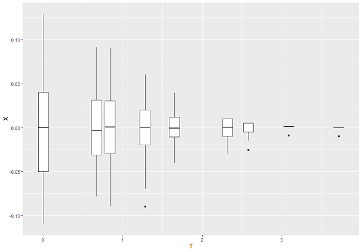

## 4.2 When n=10^3,

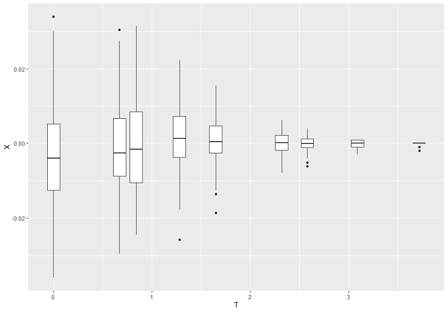

## 4.3 When n=10^4,

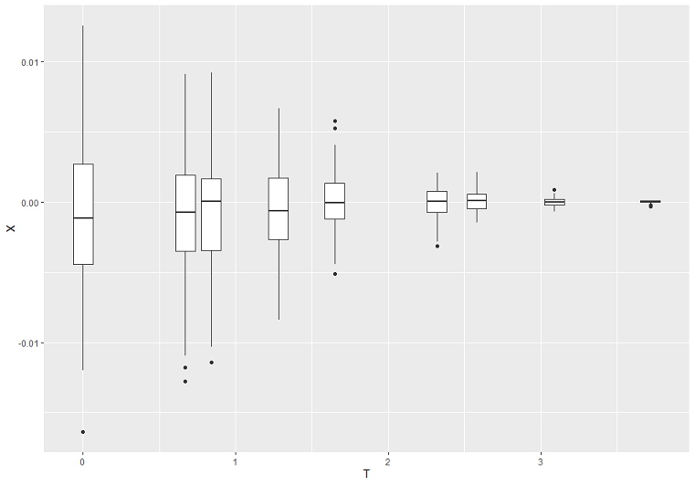

# 5 Conclusion

I form a table by experiencing with the approximation at different values of n and t, and draw box plots of the 100 approximation errors at each t using ggplot2 for each n. As you can see from the above three boxplots, the error range is smaller and closer to zero as n increases, and the error range is also smaller and closer to zero as t increases.